# Bioestadistica con R

### 2.2.2 Grafico de qqplot

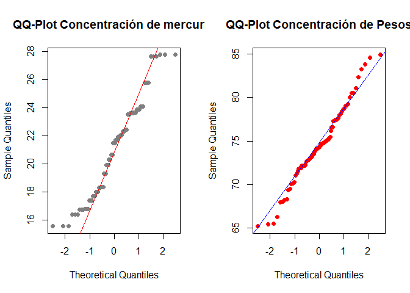

```r
##### Groficos de qq plot de la prueba de normalidad de los datos

# Establecemos un diseño de una fila y dos columnas para mostrar dos gráficos QQ-Plot
par(mfcol = c(1, 2))

# Graficamos el QQ-Plot para los datos de mercurio (Hg)
qqnorm(dagraf$Hg, pch = 19, col = "gray50", main = "QQ-Plot Concentración de mercurio")
qqline(dagraf$Hg, col = "red")  # Agregamos una línea de referencia roja

# Graficamos el QQ-Plot para los datos de peso
qqnorm(dagraf$peso, pch = 19, col = "red", main = "QQ-Plot Concentración de Pesos")
qqline(dagraf$peso, col = "blue")  # Agregamos una línea de referencia azul
```

```r
# Restauramos el diseño de una sola celda
par(mfcol = c(1, 1))
```

## 2.3 Elaboracion de grafico de cajas y bigotes

Gráfico de Boxplot 1 (dagraf$peso):

Este gráfico muestra la distribución de los datos de peso en el conjunto de datos. La caja representa el rango intercuartílico (IQR), que abarca desde el primer cuartil (Q1) hasta el tercer cuartil (Q3). La línea dentro de la caja representa la mediana (Q2), que es el valor que divide el conjunto de datos en dos partes iguales. Los “bigotes” muestran la dispersión de los datos más allá de los cuartiles, excluyendo los valores atípicos. La etiqueta del eje y indica “Frecuencia”, que es la frecuencia de ocurrencia de los diferentes valores de peso en el conjunto de datos. Gráfico de Boxplot 2 (dagraf$peso, col = “forestgreen”):

Es similar al primer gráfico, pero con una diferencia de color. En este caso, la caja y los puntos del gráfico se representan en un tono verde oscuro (“forestgreen”). Gráfico de Boxplot 3 (dagraf$Hg, col = “lightblue”, main = “Diagrama de cajas concent. Mercurio”):

Este gráfico muestra la distribución de los datos de concentración de mercurio en el conjunto de datos. Se establece la etiqueta del eje y como “frecuencias”, lo que sugiere que la frecuencia de ocurrencia de los diferentes valores de concentración de mercurio se está representando. La caja y los puntos del gráfico se muestran en un tono azul claro (“lightblue”). Además, se proporciona un título al gráfico, que es “Diagrama de cajas concent. Mercurio”.

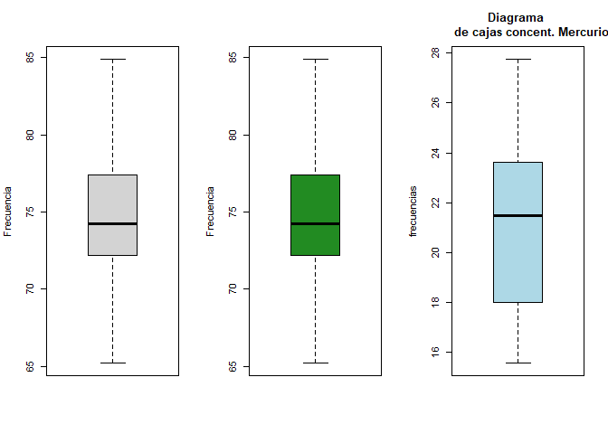

```r
par(mfcol = c(1, 3))
## gr?ficos de boxplots o cajas
boxplot(dagraf$peso, ylab = "Frecuencia")
boxplot(dagraf$peso, ylab = "Frecuencia", col = "forestgreen")
boxplot(dagraf$Hg, ylab = "frecuencias", col= "lightblue", main= "Diagrama
        de cajas concent. Mercurio")
```

```r
par(mfcol = c(1, 1))
```

## 2.4 Manipular elementos de caja y vigotes

Definición de colores:

Se definen dos vectores de colores (col.g1 y col.g2) que se utilizarán en los gráficos de caja para representar diferentes regiones. Boxplot por Región:

Se crea un gráfico de caja donde el eje x representa las regiones y el eje y representa el peso en kg. Se utilizan los colores definidos en col.g2 para cada región. El parámetro vertical = TRUE indica que los gráficos de caja se mostrarán en posición vertical. Se establecen tamaños de letra para los ejes (cex.axis) y etiquetas (cex.lab). Se proporciona un título al gráfico. Boxplot por Región (sintaxis alternativa):

Se muestra otro gráfico de caja utilizando una sintaxis alternativa donde se especifica el nombre de la variable (peso) y el nombre del conjunto de datos (dagraf) directamente. Boxplot por Sexo:

Se genera un gráfico de caja separando los datos de peso por género (macho y hembra). Boxplot por Región y Sexo:

Se crea un gráfico de caja donde se compara el peso según la región y el género. Boxplot por Región y Sexo (horizontal):

Similar al gráfico anterior, pero se muestra en posición horizontal (horizontal = TRUE), con ejes de menor tamaño (cex.axis = 0.6) y etiquetas de ejes giradas (las = 2). Personalización adicional de Boxplot por Región:

Otro gráfico de caja por región, con colores diferentes (yellow, blue, forestgreen) y etiquetas de región personalizadas (names = c(“PN”, “Central”, “Sur”)). Estos gráficos de caja permiten comparar la distribución del peso en diferentes regiones y géneros, lo que puede ayudar a identificar patrones o diferencias significativas en los datos. Además, la personalización de colores y otros parámetros permite ajustar el aspecto de los gráficos para satisfacer las necesidades específicas de visualización.

```r
# Manipular elementos del grofico
levels(dagraf$region)
```

```
## [1] "Pacifico Norte"   "Pacifico Central" "Pacifico Sur"
```

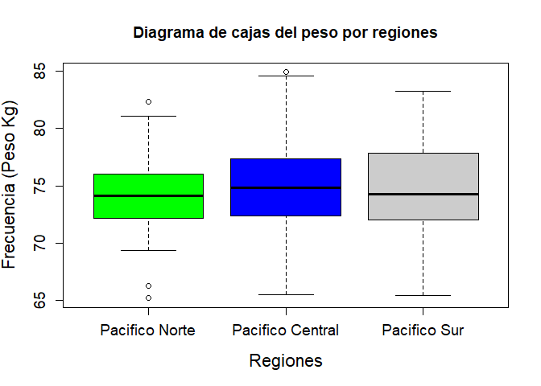

```r
col.g1 = c("green", "blue", "grey80") # definir colores
col.g2 = c("GREEN", "blue", "grey80") # definir colores

boxplot(dagraf$peso ~ dagraf$region,
        xlab = "Regiones", ylab="Frecuencia (Peso Kg)", col = col.g2, vertical = T,
        cex.axis = 1.2, cex.lab = 1.4,
        main = "Diagrama de cajas del peso por regiones") #el vertical puedo cambiar a horizontal
```

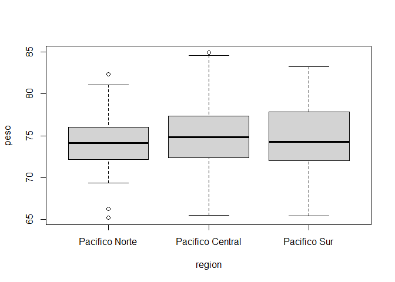

```r
boxplot(peso ~ region, data = dagraf)
```

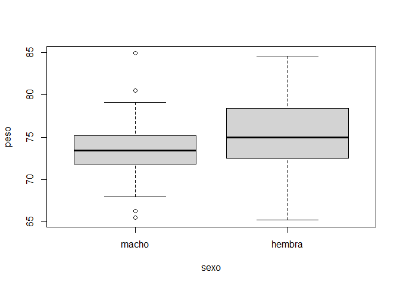

```r
boxplot(peso ~ sexo, data = dagraf)
```

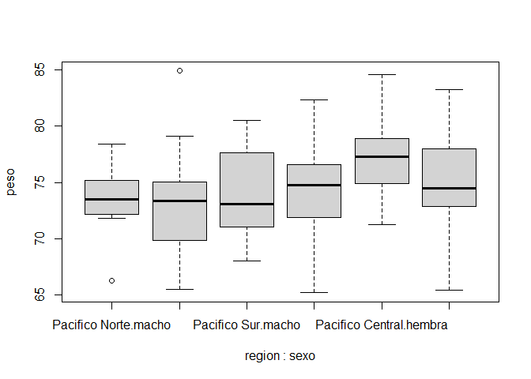

```r
boxplot(peso ~ region + sexo, data = dagraf)
```

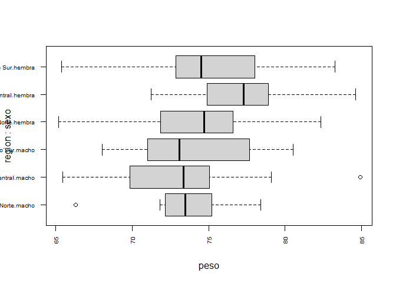

```r
boxplot(peso ~ region + sexo, data = dagraf,
        horizontal = TRUE, cex.axis = 0.6, las = 2)
```

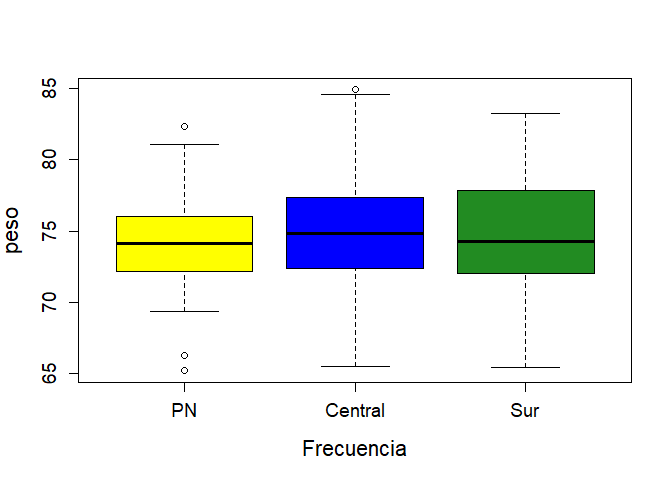

```r
boxplot(peso ~ region, data = dagraf,
        xlab = "Frecuencia",
        col = c("yellow", "blue", "forestgreen"),
        vertical = T,
        cex.axis = 1.2, cex.lab = 1.4,
        names = c("PN", "Central", "Sur"))
```

```r
# Establecer margenes
```

Elaboracion de boxplot de forma nativa de boxplot

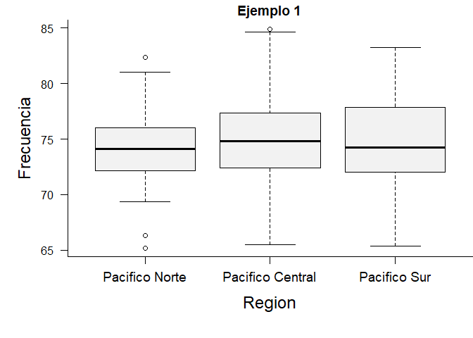

```r
# Establecer margenes
par(mfcol = c(1, 1))
par(mar = c(6, 5, 1.5, 0))

boxplot(peso ~ region, data = dagraf,
        col = "gray95",
        xlab = "", ylab = "",
        type = "n",xaxt = "n", yaxt = "n",
        frame.plot = F, main = "Ejemplo 1")

axis(1, at = seq(1, 3, by = 1),
     labels = c("Pacifico Norte", "Pacifico Central", "Pacifico Sur"),
     cex.axis = 1.2)

axis(2, las = 1)

mtext("Region", side = 1, line = 3, cex = 1.5)
mtext("Frecuencia", side = 2, line = 2.6, cex = 1.5)

box(bty="l",lwd=1.1)
```

# 3 *test estadisticos basicos*

## 3.1 test de Normalidad Shapiro-Wilk

```r
# instalamos un paquete que trae sobre pruebas de normalidad
library("nortest")
#Desarrollando el test de Normalidad

#### Test de Shapiro-Wilk

#Este test se emplea para contrastar normalidad cuando el
#tamaño de la muestra es menor de 50. Para muestras grandes
#es equivalente al test de kolmogorov-Smirnov.

library("dplyr")
library("ggpubr")

#Datos de medidas de dientes
#H0 : las medidas de los dientes siguen una tendencia de normalidad.
#HA : las medidas de los dientes no siguen una tendencia de normalidad.

#Ejemplo 1

quirus=ToothGrowth  # Asignamos los datos

str(quirus)         # Estructura de los datos
```

```
## 'data.frame':    60 obs. of  3 variables:
##  $ len : num  4.2 11.5 7.3 5.8 6.4 10 11.2 11.2 5.2 7 ...
##  $ supp: Factor w/ 2 levels "OJ","VC": 2 2 2 2 2 2 2 2 2 2 ...
##  $ dose: num  0.5 0.5 0.5 0.5 0.5 0.5 0.5 0.5 0.5 0.5 ...
```

```r
summary(quirus)     # Estadistica basica
```

```
##       len        supp         dose
##  Min.   : 4.20   OJ:30   Min.   :0.500
##  1st Qu.:13.07   VC:30   1st Qu.:0.500
##  Median :19.25           Median :1.000
##  Mean   :18.81           Mean   :1.167
##  3rd Qu.:25.27           3rd Qu.:2.000
##  Max.   :33.90           Max.   :2.000
```

```r
sd(quirus$dose)     # Desviacion estandar de dosis
```

```
## [1] 0.6288722
```

```r
sd(quirus$len)      # desviacion estandar de la longitud de los dientes
```

```
## [1] 7.649315
```

```r
var(quirus$dose)
```

```
## [1] 0.3954802
```

```r
var(quirus$len)
```

```
## [1] 58.51202
```

Los datos del conjunto “quirus” corresponden a un estudio sobre el crecimiento dental en sujetos expuestos a diferentes dosis de una sustancia (“supp”) y midiendo la longitud de los dientes (“len”). La estructura del conjunto de datos es la siguiente:

len: Variable numérica que representa la longitud de los dientes. supp: Factor con 2 niveles (“OJ” y “VC”) que indica el tipo de suplemento utilizado. dose: Variable numérica que indica la dosis de la sustancia administrada. El resumen estadístico de “quirus” muestra que:

La longitud de los dientes (“len”) tiene una media de aproximadamente 18.81 unidades, con una mínima de 4.20 y una máxima de 33.90. La desviación estándar es de aproximadamente 7.65 y la varianza es de alrededor de 58.51. La dosis (“dose”) tiene una media de aproximadamente 1.167 unidades, con una mínima de 0.5 y una máxima de 2. La desviación estándar es de aproximadamente 0.63 y la varianza es de alrededor de 0.40. Estos estadísticos describen la distribución y variabilidad de las medidas de longitud de los dientes y las dosis administradas en el estudio. Las medidas de longitud tienen una mayor variabilidad en comparación con las dosis administradas, como lo sugieren las desviaciones estándar y las varianzas más altas.

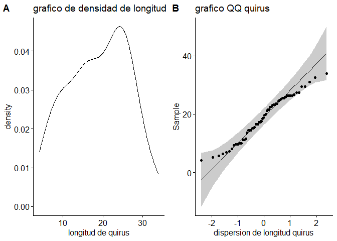

```r
library(ggpubr)
#grafico de densidad
A= ggdensity(quirus$len, main = "grafico de densidad de longitud de quirus",
          xlab="longitud de quirus")

#gr?fico qqplot
B = ggqqplot(quirus$len, main= "grafico QQ quirus",
         xlab="dispersion de longitud quirus")

C= ggarrange(A,B,
               labels = c("A", "B"),
               nrow = 1,ncol = 2)
C
```

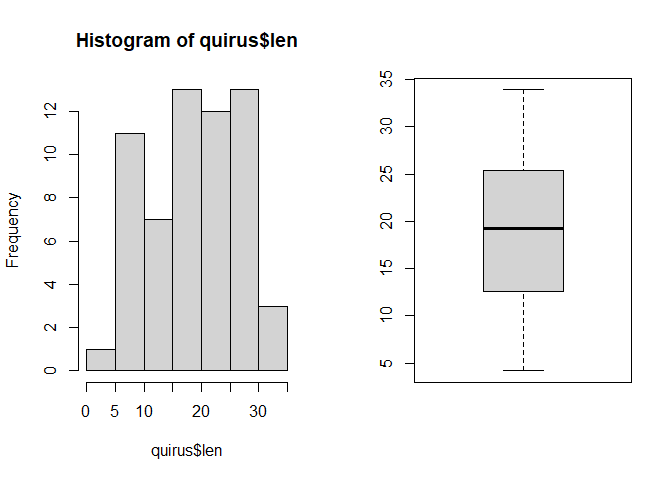

```r
par(mfcol = c(1, 2))
#histograma
hist(quirus$len)
#boxplot
boxplot(quirus$len)
```

```r
par(mfcol = c(1, 1))
```

## 3.2 test de Normalidad de Kolmogorov-Smirnov

El resultado del test de normalidad de Lilliefors (que es una variante del test de Kolmogorov-Smirnov) se interpreta de la siguiente manera:

Para el conjunto de datos “quirus$len” (longitud de los dientes), el valor p obtenido es 0.172. Este valor p es mayor que el nivel de significancia comúnmente utilizado (0.05), lo que indica que no hay suficiente evidencia para rechazar la hipótesis nula de normalidad. Por lo tanto, podemos asumir que los datos de longitud de los dientes siguen una distribución normal.

```r
#aplicando el test shapiro para conocer la tendencia de los datos
lillie.test(quirus$len) #test de normalidad de Kolmogorov-Smirnov
```

```
##
##  Lilliefors (Kolmogorov-Smirnov) normality test
##
## data:  quirus$len
## D = 0.097092, p-value = 0.172
```

```r
lillie.test(dagraf$peso) #test de normalidad de Kolmogorov-Smirnov
```

```
##
##  Lilliefors (Kolmogorov-Smirnov) normality test
##
## data:  dagraf$peso
## D = 0.094151, p-value = 0.07286
```

```r
lillie.test(dagraf$Hg)
```

```
##
##  Lilliefors (Kolmogorov-Smirnov) normality test
##
## data:  dagraf$Hg
## D = 0.12007, p-value = 0.00568
```

### 3.2.1 Grafico de QQ - Plot

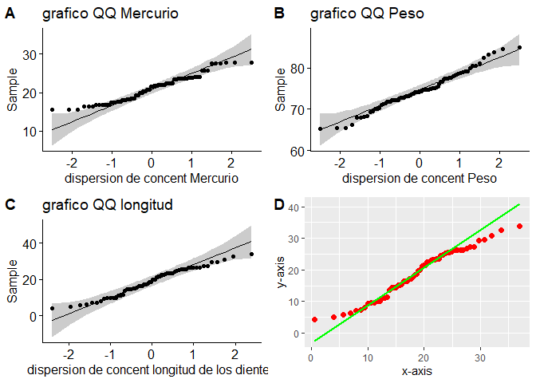

```r
A= ggqqplot(dagraf$Hg, main= "grafico QQ Mercurio",
         xlab="dispersion de concent Mercurio")

B= ggqqplot(dagraf$peso, main= "grafico QQ Peso",
         xlab="dispersion de concent Peso")

C= ggqqplot(quirus$len, main= "grafico QQ longitud ",
         xlab="dispersion de concent longitud de los dientes")

library(ggplot2)
library(caTools)
library(benchmarkme)
library(memuse)
library(robustbase)
library(qqplotr)
# ploting data with proper labels
# And adding line with proper properties

D =ggplot(mapping = aes(sample = quirus$len)) +
  stat_qq_point(size = 2,color = "red") +
  stat_qq_line(color="green") +
  xlab("x-axis") + ylab("y-axis")

E= ggarrange(A,B,C,D,
             labels = c("A", "B", "C", "D"),
             nrow = 2,ncol = 2)
E
```

### 3.2.2 test de Normalidad de Kolmogorov-Smirnov y modificacion de Lillefors

Se realiza una prueba de Kolmogorov-Smirnov (KS) para determinar si los datos de longitud de los dientes (quirus$len) provienen de una distribución normal. El KS test permite estudiar si una muestra procede de una población con una determinada distribución, no limitándose únicamente a la distribución normal.

En el código proporcionado, se utiliza la función ks.test() para llevar a cabo esta prueba. Los argumentos son:

x: Los datos que se están evaluando (quirus.len).pnorm: La distribución teórica de referencia que se está probando, en este caso, la distribución normal. mean(quirus.len): La media de los datos de longitud de los dientes. sd(quirus$len): La desviación estándar de los datos de longitud de los dientes. La salida del código proporcionará el resultado del KS test, indicando si hay suficiente evidencia para rechazar la hipótesis nula de que los datos provienen de una distribución normal o no.

```r
#El test de Kolmogorov-Smirnov permite estudiar si una muestra
#procede de una poblacion con una determinada distribucion
#(media y desviacion topica), no esta limitado unicamente
#a la distribuci?n normal. Se ejecuta con la funcion ks.test().

mtcars
```

|  | mpg | cyl | disp | hp | drat | wt | qsec | vs | am | gear | carb |
| --- | --- | --- | --- | --- | --- | --- | --- | --- | --- | --- | --- |
| Mazda RX4 | 21.0 | 6 | 160.0 | 110 | 3.90 | 2.620 | 16.46 | 0 | 1 | 4 | 4 |
| Mazda RX4 Wag | 21.0 | 6 | 160.0 | 110 | 3.90 | 2.875 | 17.02 | 0 | 1 | 4 | 4 |
| Datsun 710 | 22.8 | 4 | 108.0 | 93 | 3.85 | 2.320 | 18.61 | 1 | 1 | 4 | 1 |
| Hornet 4 Drive | 21.4 | 6 | 258.0 | 110 | 3.08 | 3.215 | 19.44 | 1 | 0 | 3 | 1 |
| Hornet Sportabout | 18.7 | 8 | 360.0 | 175 | 3.15 | 3.440 | 17.02 | 0 | 0 | 3 | 2 |
| Valiant | 18.1 | 6 | 225.0 | 105 | 2.76 | 3.460 | 20.22 | 1 | 0 | 3 | 1 |
| Duster 360 | 14.3 | 8 | 360.0 | 245 | 3.21 | 3.570 | 15.84 | 0 | 0 | 3 | 4 |
| Merc 240D | 24.4 | 4 | 146.7 | 62 | 3.69 | 3.190 | 20.00 | 1 | 0 | 4 | 2 |
| Merc 230 | 22.8 | 4 | 140.8 | 95 | 3.92 | 3.150 | 22.90 | 1 | 0 | 4 | 2 |
| Merc 280 | 19.2 | 6 | 167.6 | 123 | 3.92 | 3.440 | 18.30 | 1 | 0 | 4 | 4 |

[output cut: 22 more lines]

```r
ks.test(x = quirus$len,"pnorm", mean(quirus$len), sd(quirus$len))
```

```
##
##  Asymptotic one-sample Kolmogorov-Smirnov test
##
## data:  quirus$len
## D = 0.097092, p-value = 0.6237
## alternative hypothesis: two-sided
```

# 4 *T Student, una muestra*

## 4.1 test de Normalidad Shapiro-Wilk

El estadistico aplicado es el t-student.

```r
#Recomendado para trabajar con muestras peque?as.
#Sin embargo, cuando se trabaja con muestras grandes
#los datos son pr?ximos a una distribuci?n aproximadamente normal.

#Ejemplo 1
#Se realiza un experimento donde se midio la produccion de
#vainas de frijol por cada mata producida, en 12 unidades
#experimentales sometidas bajo las mismas condiciones.

frijol = c(18,11,17,10,20,25,13,16,25,20,19,20)
```

Hipotesis

H0= Los datos provienen de una distribuci?n normal. H1: Los datos presentan una distribuci?n asim?trica.

Probamos el supuesto de normalidad de nuestros datos

```r
shapiro.test(frijol) #shapiro me dice que hay tendencia a la normalidad
```

```
##
##  Shapiro-Wilk normality test
##
## data:  frijol
## W = 0.9413, p-value = 0.5152
```

Aceptamos H0: Nuestros datos cumplen con el supuesto de normalidad.

Estime el intervalo de confianza al 95% para el rendimiento promedio del numero de vainas producidas por cada mata de frijol. Los datos presentan una distribucion normal.

Soluci?n:

El intervalo de confianza es construido a trav?s de la prueba t.test (x)

```r
t.test(frijol)
```

```
##
##  One Sample t-test
##
## data:  frijol
## t = 12.864, df = 11, p-value = 5.673e-08
## alternative hypothesis: true mean is not equal to 0
## 95 percent confidence interval:
##  14.78220 20.88447
## sample estimates:
## mean of x
##  17.83333
```

```r
#El intervalo de confianza al 95% obtenido es: [14.78 a 20.88],
#lo que representa es el intervalo de la media de la poblaci?n de
#las vainas de frijol. As? mismo se obtienen otros resultados
#como la media de la muestra de: 17.83.

#Se nos brinda informaci?n adicional del valor calculado de t=12.86,
#los grados de libertad (df=11), obtenidos de la
#formula gl=n-1 (numero de observaciones menos uno), y
#la probabilidad resultante (p-value = 5.673e-08), en nuestro caso
#es menor a 0.05, por lo que nuestro resultado es significativo
#dado la hip?tesis por defecto.

#H0: media igual a 0
#H1: media es diferente de 0
```

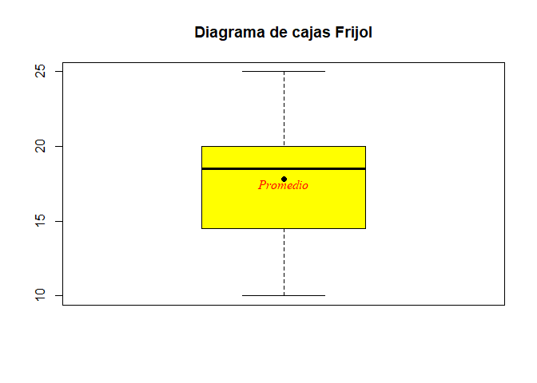

```r
#para ver gr?ficamente
boxplot(frijol,col="yellow", main="Diagrama de cajas Frijol")
points(mean(frijol), pch=20, cex = 1.5)
text(17.5, "Promedio", col="red", font=8 )
```

```r
median(frijol)
```

```
## [1] 18.5
```

```r
#Por tanto concluimos que existe diferencia significativa en cuanto a la
#producci?n de vainas en cada planta dentro de esa muestra de 12 plantas.

#Nivel de ingreso de padres de familia en la prov. Tambopata

social=c(900,850,700,980,500,450,1025,1800,1000,640)
shapiro.test(social)
```

```
##
##  Shapiro-Wilk normality test
##
## data:  social
## W = 0.85751, p-value = 0.07132
```

```r
#H0: los salarios de los 1o padres no son significativamente diferentes
#H1: los salarios de los 1o padres si son significativamente diferentes

t.test(social)
```

```
##
##  One Sample t-test
##
## data:  social
## t = 7.3251, df = 9, p-value = 4.444e-05
## alternative hypothesis: true mean is not equal to 0
## 95 percent confidence interval:
##   611.3474 1157.6526
## sample estimates:
## mean of x
##     884.5
```

```r
#conclusiOn

#El valor de la  p-value = 4.444e-05, nos indica que significativamente hay
#una diferencia en los salarios de los 10 pdf.
```

## 4.2 T Test para 2 muestras independientes

```r
#El dataset births del paquete openintro contiene informaci?n sobre
#150 nacimientos junto con informaci?n de las madres.
#Se quiere determinar si existen evidencias significativas de que el
#peso de los reci?n nacidos cuyas madres fuman (f) difiere de aquellos
#cuyas madres no fuman (nf).

#install.packages("openintro") #necesitamos de estos paquetes para trabajar
#la base de satos births
library(openintro)
#install.packages("tidyverse")
library(tidyverse)
data(births)
head(births, 4)
```

| f_age | m_age | weeks | premature | visits | gained | weight | sex_baby | smoke |
| --- | --- | --- | --- | --- | --- | --- | --- | --- |
| 31 | 30 | 39 | full term | 13 | 1 | 6.88 | male | smoker |
| 34 | 36 | 39 | full term | 5 | 35 | 7.69 | male | nonsmoker |
| 36 | 35 | 40 | full term | 12 | 29 | 8.88 | male | nonsmoker |
| 41 | 40 | 40 | full term | 13 | 30 | 9.00 | female | nonsmoker |

```r
print(births)
```

```
## # A tibble: 150 × 9
##    f_age m_age weeks premature visits gained weight sex_baby smoke
##    <int> <int> <int> <fct>      <int>  <int>  <dbl> <fct>    <fct>
##  1    31    30    39 full term     13      1   6.88 male     smoker
##  2    34    36    39 full term      5     35   7.69 male     nonsmoker
##  3    36    35    40 full term     12     29   8.88 male     nonsmoker
##  4    41    40    40 full term     13     30   9    female   nonsmoker
##  5    42    37    40 full term     NA     10   7.94 male     nonsmoker
##  6    37    28    40 full term     12     35   8.25 male     smoker
##  7    35    35    28 premie         6     29   1.63 female   nonsmoker
##  8    28    21    35 premie         9     15   5.5  female   smoker
##  9    22    20    32 premie         5     40   2.69 male     smoker
## 10    36    25    40 full term     13     34   8.75 female   nonsmoker
## # ℹ 140 more rows
```

```r
str(births)
```

```
## tibble [150 × 9] (S3: tbl_df/tbl/data.frame)
##  $ f_age    : int [1:150] 31 34 36 41 42 37 35 28 22 36 ...
##  $ m_age    : int [1:150] 30 36 35 40 37 28 35 21 20 25 ...
##  $ weeks    : int [1:150] 39 39 40 40 40 40 28 35 32 40 ...
##  $ premature: Factor w/ 2 levels "full term","premie": 1 1 1 1 1 1 2 2 2 1 ...
##  $ visits   : int [1:150] 13 5 12 13 NA 12 6 9 5 13 ...
##  $ gained   : int [1:150] 1 35 29 30 10 35 29 15 40 34 ...
##  $ weight   : num [1:150] 6.88 7.69 8.88 9 7.94 8.25 1.63 5.5 2.69 8.75 ...
##  $ sex_baby : Factor w/ 2 levels "female","male": 2 2 2 1 2 2 1 1 2 1 ...
##  $ smoke    : Factor w/ 2 levels "nonsmoker","smoker": 2 1 1 1 1 2 1 2 2 1 ...
```

```r
# 1. Hip?tesis

#H0: no hay diferencia entre las medias poblacionales: ??(nf)?????(f)=0
#Ha: si hay diferencia entre las medias poblacionales: ??(nf)?????(f)???0


#2. Par?metro estimado (estad?stico)
#Diferencia entre las medias muestrales:

smoker = births %>% filter(smoke == "smoker") %>% pull(weight)
nonsmoker = births %>% filter(smoke == "nonsmoker") %>% pull(weight)

mean(nonsmoker) - mean(smoker)
```

```
## [1] 0.4005
```

```r
#3. Condiciones para aplicar un t-test
#Independencia: Se trata de un muestreo aleatorio donde el
#tama?o de las muestras no supera el 10% de todos los nacimientos
#Se puede afirmar que los eventos son independientes.
```

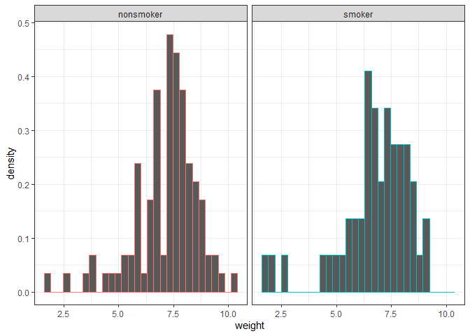

```r
#Normalidad:
#muestra el histograma ggplo2
ggplot(births,aes(x = weight)) +
  geom_histogram(aes(y = ..density.., colour = smoke)) +
  facet_grid(.~ smoke) +
  theme_bw() + theme(legend.position = "none")
```

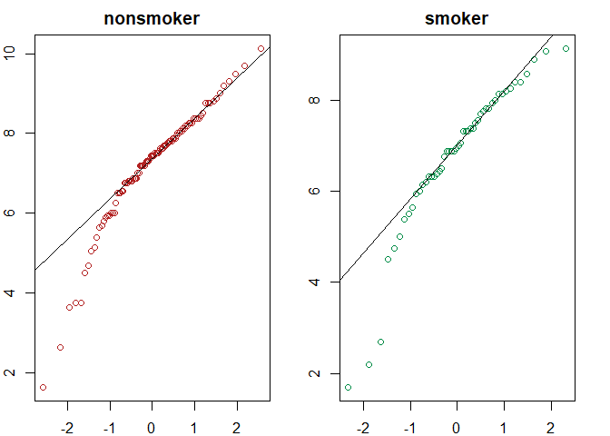

```r
# Para observar en los otros gr?ficos
par(mar = c(2, 2, 2, 2))
par(mfrow = c(1, 2))
qqnorm(nonsmoker, xlab = "", ylab = "",
       main = "nonsmoker", col = "firebrick")
qqline(nonsmoker)
qqnorm(smoker, xlab = "", ylab = "",
       main = "smoker", col = "springgreen4")
qqline(smoker)
```

```r
par(mfrow = c(1, 1))
```

```r
#Aplico el test de normalidad
shapiro.test(smoker)
```

```
##
##  Shapiro-Wilk normality test
##
## data:  smoker
## W = 0.89491, p-value = 0.0003276
```

```r
shapiro.test(nonsmoker)
```

```
##
##  Shapiro-Wilk normality test
##
## data:  nonsmoker
## W = 0.92374, p-value = 2.234e-05
```

```r
#Los gr?ficos qqnorm muestran asimetr?a hacia la izquierda y los test
#encuentran evidencias significativas de que los datos no
#proceden de poblaciones con distribuci?n normal. Sin embargo,
#dado que el tama?o de cada grupo es mayor que 30 se puede considerar
#que el t-test sigue siendo suficientemente robusto, aunque es necesario
#mencionarlo en las conclusiones.
# Un test no param?trico basado en la
#mediana (Mann-Withney-Wilcoxon test) o un test de Bootstraping ser?an m?s
#adecuados. Otra opci?n ser?a estudiar si los datos an?malos son excepciones
#que se pueden excluir del an?lisis.
```

```r
#Datos de crecimiento de plantulas con perturbio y no perturbio, consideramos
#muestras pareadas porque sobre el mismo tratamiento estoy desarrollando


plantulas = read_excel("plantulas.xls", sheet=1)

#H0=el nro de plantulas entre parcelas, del testigo y del evento sean similares
#HA=el nro de plantulas entre parcelas, del testigo y del evento son diferentes

str(plantulas)  # Estructura de los datos
```

```
## tibble [17 × 4] (S3: tbl_df/tbl/data.frame)
##  $ Par       : num [1:17] 1 2 3 4 5 6 7 8 9 10 ...
##  $ Testigo   : num [1:17] 113 98 98 83 94 89 88 122 69 113 ...
##  $ Perterbado: num [1:17] 89 118 123 87 100 105 125 189 141 96 ...
##  $ Diferencia: num [1:17] -24 20 25 4 6 16 37 67 72 -17 ...
```

```r
head(plantulas)
```

| Par | Testigo | Perterbado | Diferencia |
| --- | --- | --- | --- |
| 1 | 113 | 89 | -24 |
| 2 | 98 | 118 | 20 |
| 3 | 98 | 123 | 25 |
| 4 | 83 | 87 | 4 |
| 5 | 94 | 100 | 6 |
| 6 | 89 | 105 | 16 |

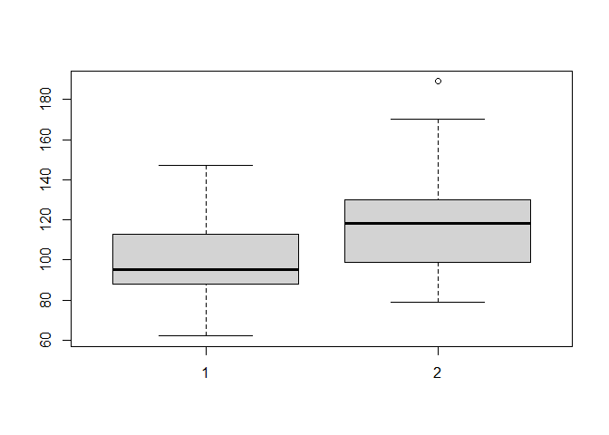

```r
boxplot(plantulas$Testigo, plantulas$Perterbado) # boxplot de dos columnas de los datos
```

```r
shapiro.test(plantulas$Testigo)  # el p valor es mayor a 0.05 por lo cual si cumple con la normaldiad
```

```
##
##  Shapiro-Wilk normality test
##
## data:  plantulas$Testigo
## W = 0.96311, p-value = 0.6906
```

```r
shapiro.test(plantulas$Perterbado) # Si cumple la normaldiad
```

```
##
##  Shapiro-Wilk normality test
##
## data:  plantulas$Perterbado
## W = 0.91884, p-value = 0.1412
```

```r
t.test(plantulas$Testigo, plantulas$Perterbado, paired = T)
```

```
##
##  Paired t-test
##
## data:  plantulas$Testigo and plantulas$Perterbado
## t = -2.5981, df = 16, p-value = 0.01942
## alternative hypothesis: true mean difference is not equal to 0
## 95 percent confidence interval:
##  -33.434853  -3.388676
## sample estimates:
## mean difference
##       -18.41176
```

```r
#Aplico el de muestras pareadas

#Conclusiones
# existe diferencia significativa entre el nro de pl?ntulas evaluadas entre
# las parcelas testigo y las perturbadas.
```

## 4.3 Prueba no parametrica de Man Wihtney o Wilcoxon

Nos reconoce a traves del test de wilcoxon. Esta prueba es para comparar dos muestras que no tienen tendencia a una distribucion de normalidad

```r
#instalamos paquete Boot
library("boot")
library("car")
library("dplyr")
library("ggpubr")

#trabajamos con el archivo fumasa
fumones = read.table("fumasa.txt", header=T)
names(fumones)
```

```
## [1] "capulmonar" "edad"       "altura"     "fuman"      "genero"
## [6] "adiccion"
```

```r
fumones
```

| capulmonar | edad | altura | fuman | genero | adiccion |
| --- | --- | --- | --- | --- | --- |
| 6.475 | 6 | 62.1 | no | masculino | no |
| 10.125 | 18 | 74.7 | si | femenino | no |
| 9.550 | 16 | 69.7 | no | femenino | si |
| 11.125 | 14 | 71.0 | no | masculino | no |
| 4.800 | 5 | 56.9 | no | masculino | no |
| 6.225 | 11 | 58.7 | no | femenino | no |
| 4.950 | 8 | 63.3 | no | masculino | si |
| 7.325 | 11 | 70.4 | no | masculino | no |
| 8.875 | 15 | 70.5 | no | masculino | no |
| 6.800 | 11 | 59.2 | no | masculino | no |

[output cut: 715 more lines]

```r
fumones=data.frame(fumones)
```

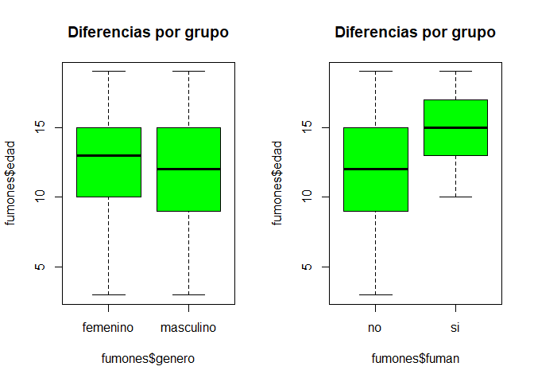

```r
par(mfrow = c(1, 2))
boxplot(fumones$edad ~ fumones$genero, col = "green",
        main = "Diferencias por grupo")

#para los que fuman y no fuman
boxplot(fumones$edad ~ fumones$fuman, col = "green",
        main = "Diferencias por grupo")
```

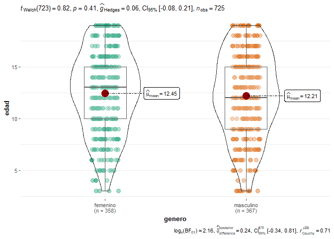

```r
par(mfrow = c(1, 1))

library(ggstatsplot)
data = data.frame(edad= c(fumones$edad),
                  genero =(fumones$genero))

ggbetweenstats(data, genero, edad,

               type = "p",
               conf.level = 0.95)
```

```r
#Selecciono para aplicar el test de normalidad
sifuman = fumones %>% filter(fuman == "si") %>% pull(edad)
nofuman = fumones %>% filter(fuman == "no") %>% pull(edad)

mean(sifuman) - mean(nofuman)
```

```
## [1] 2.743727
```

```r
#Aplico el test de normalidad para validar la no normalidad
shapiro.test(sifuman)
```

```
##
##  Shapiro-Wilk normality test
##
## data:  sifuman
## W = 0.92949, p-value = 0.0003636
```

```r
shapiro.test(nofuman)  #validamos la no tendencia a la normalidad
```

```
##
##  Shapiro-Wilk normality test
##
## data:  nofuman
## W = 0.97507, p-value = 4.708e-09
```

Existe diferencias significativas por que el p valor es menor a 0.05

```r
#Aplico el test de Mann Wihtne (wilcox.tes)
wilcox.test(edad~fuman, fumones)
```

```
##
##  Wilcoxon rank sum test with continuity correction
##
## data:  edad by fuman
## W = 15020, p-value = 1.013e-08
## alternative hypothesis: true location shift is not equal to 0
```